# Week 6 Exercises

# Exercise 1

The data frames df_w and df_f represent repeated measures data from 60 participants. Variables F1-F3 and W1-W3 are “sub-variables” that will be used to make two composite variables F_total and W_total, respectively.

#### 1.1

Merge the two data frames together.

```r
df_f <- df_f %>%
  mutate(session=factor(session))
df_fw <- full_join(df_f, df_w, by = c("id", "session", "group"))
```

#### 1.2

Using the merged data frame, create the **composite variables F_total and W_total, which are the sums of F1-F3 and W1-W3, respectively** (i.e. their values can range from 0 to 9).

```r
df_fw <- df_fw %>%
  mutate(F_total = rowSums(.[4:6])) %>%
  mutate(W_total = rowSums(.[7:9]))
```

# Exercise 2

#### 2.1

Visualise the distributions of F_total and W_total for the two groups and measurement sessions (for example as boxplots).

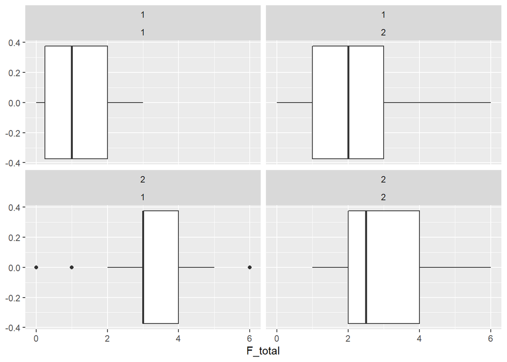

```r
df_fw %>%
  ggplot(aes(F_total)) +
  geom_boxplot() +
  facet_wrap(group~session)
```

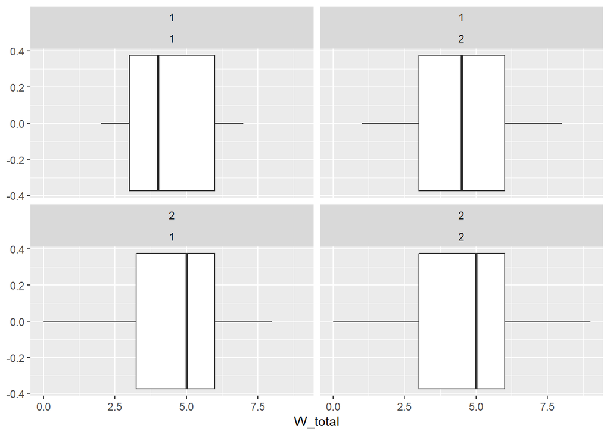

```r
df_fw %>%
  ggplot(aes(W_total)) +
  geom_boxplot() +
  facet_wrap(group~session)
```

#### 2.2

Fit a linear regression model with F_total as the DV, and session and group as predictors.

```r
str(df_fw)
```

```
## 'data.frame':    120 obs. of  11 variables:
##  $ id     : chr  "1" "1" "2" "2" ...
##  $ session: Factor w/ 2 levels "1","2": 2 1 2 1 2 1 2 1 2 1 ...
##  $ group  : Factor w/ 2 levels "1","2": 1 1 1 1 1 1 1 1 1 1 ...
##  $ F1     : num  0 3 2 0 1 0 2 2 1 1 ...
##  $ F2     : num  0 0 0 0 0 0 0 0 0 0 ...
##  $ F3     : num  3 0 2 0 0 0 2 0 0 0 ...
##  $ W1     : num  1 2 3 0 0 3 1 3 2 2 ...
##  $ W2     : num  0 3 2 2 3 2 0 1 1 0 ...
##  $ W3     : num  0 2 0 1 3 0 1 2 1 1 ...
##  $ F_total: num  3 3 4 0 1 0 4 2 1 1 ...
##  $ W_total: num  1 7 5 3 6 5 2 6 4 3 ...
```

```r
F.model <- lm(F_total ~ group + session, data = df_fw)

summary(F.model)
```

```
##
## Call:
## lm(formula = F_total ~ group + session, data = df_fw)
##
## Residuals:
##     Min      1Q  Median      3Q     Max
## -2.9667 -1.2000  0.0333  1.0333  4.0333
##
## Coefficients:
##             Estimate Std. Error t value Pr(>|t|)
## (Intercept)   1.7333     0.2422   7.156 7.84e-11 ***
## group2        1.2333     0.2797   4.409 2.31e-05 ***
## session2      0.2333     0.2797   0.834    0.406
## ---
## Signif. codes:  0 '***' 0.001 '**' 0.01 '*' 0.05 '.' 0.1 ' ' 1
##
## Residual standard error: 1.532 on 117 degrees of freedom
## Multiple R-squared:  0.1469, Adjusted R-squared:  0.1323
## F-statistic: 10.07 on 2 and 117 DF,  p-value: 9.224e-05
```

#### 2.3

Look at the means of F_total by group and session. How are they linked to the linear regression model coefficients?

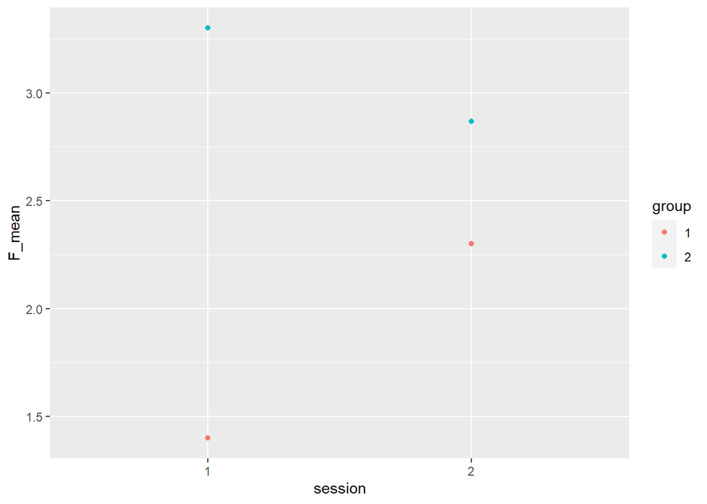

```r
df_fw <- df_fw %>%
  group_by(group, session) %>%
  mutate(F_mean = mean(F_total)) %>%
  ungroup()

df_fw %>%
  ggplot(aes(session, F_mean, color = group)) +
  geom_point()
```

```r
# The mean of F_total goes down between sessions for one group, and up for the other. So it seems there is an interaction effect. We can see if it's significant by adding it to the regression model.

F.model.2 <- lm(F_total ~ group + session + group * session, data = df_fw)

summary(F.model.2)
```

```
##
## Call:
## lm(formula = F_total ~ group + session + group * session, data = df_fw)
##
## Residuals:
##     Min      1Q  Median      3Q     Max
## -3.3000 -0.8667 -0.3000  0.7000  3.7000
##
## Coefficients:
##                 Estimate Std. Error t value Pr(>|t|)
## (Intercept)       1.4000     0.2740   5.109 1.28e-06 ***
## group2            1.9000     0.3875   4.903 3.10e-06 ***
## session2          0.9000     0.3875   2.323   0.0219 *
## group2:session2  -1.3333     0.5480  -2.433   0.0165 *
## ---
## Signif. codes:  0 '***' 0.001 '**' 0.01 '*' 0.05 '.' 0.1 ' ' 1
##
## Residual standard error: 1.501 on 116 degrees of freedom
## Multiple R-squared:  0.1883, Adjusted R-squared:  0.1673
## F-statistic: 8.969 on 3 and 116 DF,  p-value: 2.163e-05
```

# Exercise 3

Visualise the [anscombe dataset](https://rdrr.io/r/datasets/anscombe.html) using ggplot2.

```r
summary(anscombe)
```

```
##        x1             x2             x3             x4           y1
##  Min.   : 4.0   Min.   : 4.0   Min.   : 4.0   Min.   : 8   Min.   : 4.260
##  1st Qu.: 6.5   1st Qu.: 6.5   1st Qu.: 6.5   1st Qu.: 8   1st Qu.: 6.315
##  Median : 9.0   Median : 9.0   Median : 9.0   Median : 8   Median : 7.580
##  Mean   : 9.0   Mean   : 9.0   Mean   : 9.0   Mean   : 9   Mean   : 7.501
##  3rd Qu.:11.5   3rd Qu.:11.5   3rd Qu.:11.5   3rd Qu.: 8   3rd Qu.: 8.570
##  Max.   :14.0   Max.   :14.0   Max.   :14.0   Max.   :19   Max.   :10.840
##        y2              y3              y4
##  Min.   :3.100   Min.   : 5.39   Min.   : 5.250
##  1st Qu.:6.695   1st Qu.: 6.25   1st Qu.: 6.170
##  Median :8.140   Median : 7.11   Median : 7.040
##  Mean   :7.501   Mean   : 7.50   Mean   : 7.501
##  3rd Qu.:8.950   3rd Qu.: 7.98   3rd Qu.: 8.190
##  Max.   :9.260   Max.   :12.74   Max.   :12.500
```

```r
x1y1 <- lm(data = anscombe, y1 ~ x1)

x1y1
```

```
##
## Call:
## lm(formula = y1 ~ x1, data = anscombe)
##
## Coefficients:
## (Intercept)           x1
##      3.0001       0.5001
```

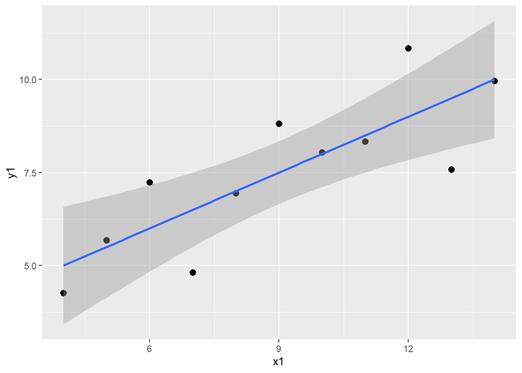

```r
ggplot(data = anscombe, aes(x1, y1)) +
  stat_summary(fun.data=mean_cl_normal) +
  geom_smooth(method='lm', formula= y~x)
```

```r
x2y2 <- lm(data = anscombe, y2 ~ x2)

x2y2
```

```
##
## Call:
## lm(formula = y2 ~ x2, data = anscombe)
##
## Coefficients:
## (Intercept)           x2
##       3.001        0.500
```

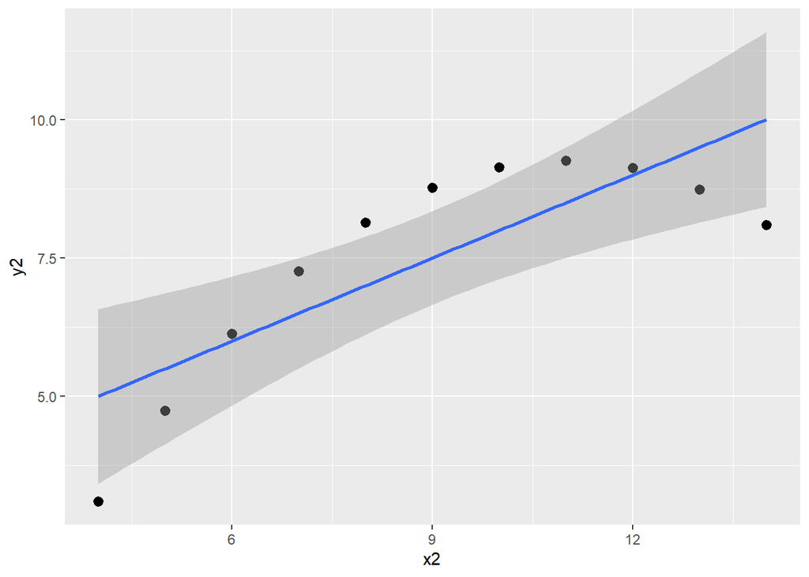

```r
ggplot(data = anscombe, aes(x2, y2)) +
  stat_summary(fun.data=mean_cl_normal) +
  geom_smooth(method='lm', formula= y~x)
```

```r
x3y3 <- lm(data = anscombe, y3 ~ x3)

x3y3
```

```
##
## Call:
## lm(formula = y3 ~ x3, data = anscombe)
##
## Coefficients:
## (Intercept)           x3
##      3.0025       0.4997
```

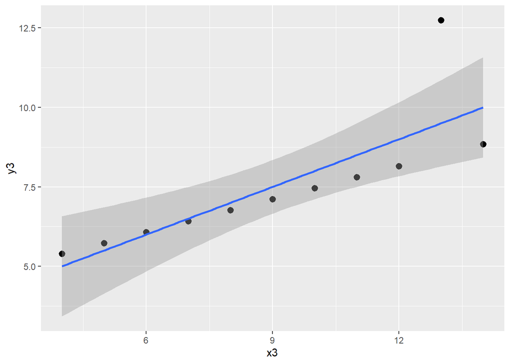

```r
ggplot(data = anscombe, aes(x3, y3)) +
  stat_summary(fun.data=mean_cl_normal) +
  geom_smooth(method='lm', formula= y~x)
```

```r
x4y4 <- lm(data = anscombe, y4 ~ x4)

x4y4
```

```
##
## Call:
## lm(formula = y4 ~ x4, data = anscombe)
##
## Coefficients:
## (Intercept)           x4
##      3.0017       0.4999
```

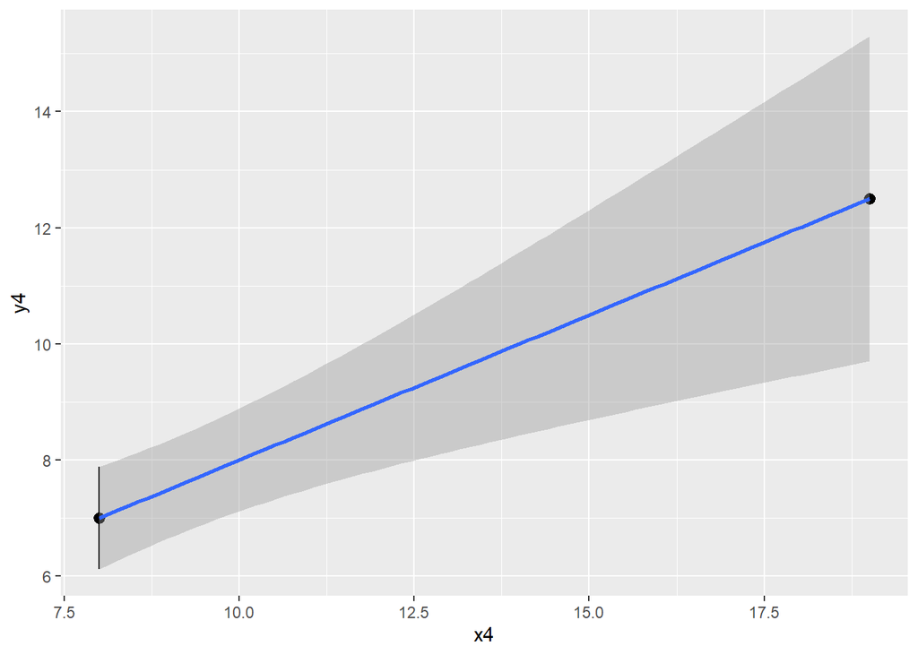

```r
ggplot(data = anscombe, aes(x4, y4)) +
  stat_summary(fun.data=mean_cl_normal) +
  geom_smooth(method='lm', formula= y~x)
```

# Exercise 4

Prepare a **separate R Notebook/Markdown document**, which will be the first draft of your final assignment with your own data. In the draft, include the following:

1. Outline the study design, your research question, DV(s), IV(s)
2. Data wrangling: start from reading in the raw data and show all steps
3. Plot your main result(s)

Even if you had already completed some of these steps before, please include all of them in your document. **NOTE: Return either a readable HTML document (.html or .nb.html), or an .Rmd file along with your data, to make it possible for us to review your work!** Make the document as professional-looking as possible (you can, of course, include your comments/questions in the draft). You will get feedback on the draft, based on which you can then make the final version. The final document should be a comprehensive report of your data wrangling process and results.